# Learning curves with scikit-learn

**Author:** Leonardo Espin

Date: 1/8/2019

```python
import pandas as pd
import numpy as np
import seaborn as sns
import matplotlib.pyplot as plt
%matplotlib inline

from sklearn.linear_model import LinearRegression,Ridge #regularized linear regression
from sklearn.model_selection import learning_curve
```

```python
#main data, cross validation data and validation datasets:
X=pd.read_csv('ex5data1-X.csv',header=None)
y=pd.read_csv('ex5data1-y.csv',header=None)
Xtest=pd.read_csv('ex5data1-Xt.csv',header=None)
ytest=pd.read_csv('ex5data1-yt.csv',header=None)
Xval=pd.read_csv('ex5data1-Xv.csv',header=None)
yval=pd.read_csv('ex5data1-yv.csv',header=None)
```

A single-variable linear regression of the main data:

```python
reg=LinearRegression().fit(X,y)
pred_y = reg.predict(X)
print(reg.coef_)
print(reg.intercept_ )
```

```
[[0.36777566]]
[13.08782802]
```

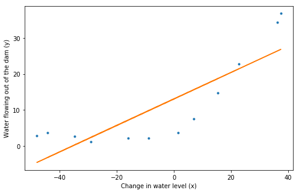

```python
plt.figure(figsize=(8,5))
plt.plot(X,y,'.');
plt.plot(X,pred_y)
plt.ylabel('Water flowing out of the dam (y)')
plt.xlabel('Change in water level (x)');
```

Clearly we won't be able to fit the data as it is. Regularization will not help either:

```python
regReg=Ridge().fit(X,y)#default lambda (called alpha in sklearn) =1
rPred_y = regReg.predict(X)
print(regReg.coef_)
print(regReg.intercept_ )
```

```
[[0.36773843]]
[13.08763867]
```

The learning curves help to characterize the problem:

```python
train_sizes,train_scores,test_scores = learning_curve(Ridge(),X,y,
                                                scoring='neg_mean_squared_error')
```

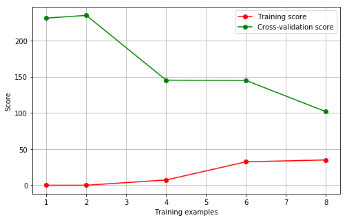

```python
plt.figure(figsize=(8,5))
plt.xlabel("Training examples")
plt.ylabel("Score")
plt.grid()

train_scores_mean = -np.mean(train_scores, axis=1)
test_scores_mean = -np.mean(test_scores, axis=1)

plt.plot(train_sizes, train_scores_mean, 'o-', color="r",label="Training score")
plt.plot(train_sizes, test_scores_mean, 'o-', color="g",label="Cross-validation score")
plt.legend(loc="best");
```

Clearly it is a **large bias** model. Both curves are converging to a large error value.

Below I merge `X` and `Xtest` because `sklearn`'s `learning_curve` takes care of doing cross validation.

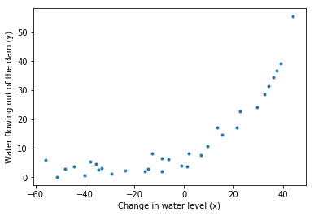

```python
Xfull=pd.concat([X,Xtest],axis=0,ignore_index=True)
yfull=pd.concat([y,ytest],axis=0,ignore_index=True)
plt.plot(Xfull,yfull,'.');
plt.ylabel('Water flowing out of the dam (y)')
plt.xlabel('Change in water level (x)');
```

To solve the large bias problem, let's add features to the data:

```python
#adding polynomial features
for i in range(7):
    Xfull[i+2]=Xfull[0].apply(lambda x: np.power(x,i+2))

Xfull.head()
```

|  | 0 | 2 | 3 | 4 | 5 | 6 | 7 | 8 |
| --- | --- | --- | --- | --- | --- | --- | --- | --- |
| 0 | -15.937 | 253.987969 | -4047.806262 | 6.450989e+04 | -1.028094e+06 | 1.638474e+07 | -2.611235e+08 | 4.161526e+09 |
| 1 | -29.153 | 849.897409 | -24777.059165 | 7.223256e+05 | -2.105796e+07 | 6.139027e+08 | -1.789710e+10 | 5.217543e+11 |
| 2 | 36.190 | 1309.716100 | 47398.625659 | 1.715356e+06 | 6.207874e+07 | 2.246630e+09 | 8.130553e+10 | 2.942447e+12 |
| 3 | 37.492 | 1405.650064 | 52700.632199 | 1.975852e+06 | 7.407865e+07 | 2.777357e+09 | 1.041287e+11 | 3.903992e+12 |
| 4 | -48.059 | 2309.667481 | -111000.309469 | 5.334564e+06 | -2.563738e+08 | 1.232107e+10 | -5.921382e+11 | 2.845757e+13 |

Repeating linear regression *without regularization*:

```python
#default lambda (called alpha in sklearn) is 1. We remove regularization by making it zero
regReg=Ridge(alpha=0,normalize=True).fit(Xfull.iloc[0:12,:],
                                         yfull.iloc[0:12])
rPred_y = regReg.predict(Xfull.iloc[0:12,:])
print(regReg.coef_)
print(regReg.intercept_ )
```

```
[[ 3.18263451e-01  2.40959734e-02  6.27155867e-04 -1.63977503e-05
  -8.28278332e-07  1.83246824e-09  3.20374087e-10  2.48306908e-12]]
[3.61277073]
```

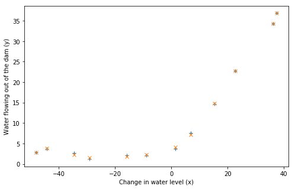

```python
plt.figure(figsize=(8,5))
plt.plot(Xfull.iloc[0:12,0],yfull.iloc[0:12],'+');
plt.plot(Xfull.iloc[0:12,0],rPred_y,'x')
plt.ylabel('Water flowing out of the dam (y)')
plt.xlabel('Change in water level (x)');
```

So now the model fits the data well. But how it will generalize to new data?

Here is were learning curves become really useful:

```python
#notice that I'm using the full dataset, since learning_curve takes care of
#doing cross validation

#import warnings #this two lines are just to make output preety here
#warnings.filterwarnings("ignore")

train_sizes,train_scores,test_scores = learning_curve(Ridge(alpha=0,normalize=True),
                                                      Xfull,yfull,
                                                      train_sizes=np.linspace(.1, 1.0, 10),
                                                scoring='neg_mean_squared_error')
```

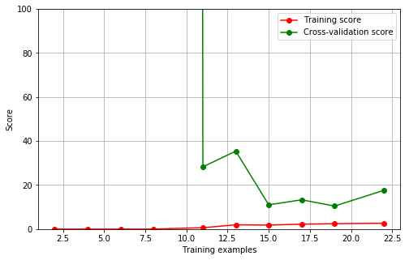

```python
plt.figure(figsize=(8,5))
plt.xlabel("Training examples")
plt.ylabel("Score")
plt.grid()
plt.ylim(top=100)

train_scores_mean = -np.mean(train_scores, axis=1)
test_scores_mean = -np.mean(test_scores, axis=1)

plt.plot(train_sizes, train_scores_mean, 'o-', color="r",label="Training score")
plt.plot(train_sizes, test_scores_mean, 'o-', color="g",label="Cross-validation score")
plt.legend(loc="best");
```

So, this example shows high variance as we add new data. The model does not generalize well.

### Choosing a regularization parameter $\lambda$

```python
lamb=[0, 0.001, 0.003, 0.01, 0.03, 0.1, 0.3, 1, 3, 10]
errT=[]
errCV=[]
mTr=len(y)
mTe=len(ytest)
for l in lamb:
    #notice the conversion from lambda to alpha below
    regReg=Ridge(alpha=l/(2*mTr),normalize=True).fit(Xfull.iloc[0:12,:],y)
    train = regReg.predict(Xfull.iloc[0:12,:])
    test=regReg.predict(Xfull.iloc[12:,:])
    errT.append(((y.values- train) ** 2).sum()/(2*mTr) )
    errCV.append(((ytest.values - test) ** 2).sum()/(2*mTe) )
```

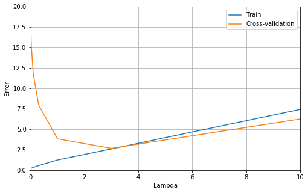

```python
plt.figure(figsize=(8,5))
plt.xlabel("Lambda")
plt.ylabel("Error")
plt.grid()
plt.ylim(top=20)
plt.xlim(left=0,right=10)
plt.plot(lamb, errT,label="Train")
plt.plot(lamb, errCV,label="Cross-validation")
plt.legend(loc="best");
```

Recalculating the learning curves with the optimal value of $\lambda$

```python
train_sizes,train_scores,test_scores = learning_curve(Ridge(alpha=3/(2*mTr),normalize=True),
                                                      Xfull,yfull,
                                                      train_sizes=np.linspace(.1, 1.0, 10),
                                                scoring='neg_mean_squared_error')
```

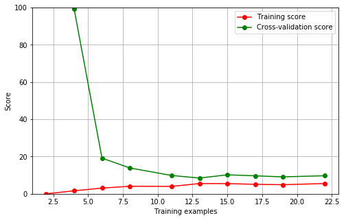

```python
plt.figure(figsize=(8,5))
plt.xlabel("Training examples")
plt.ylabel("Score")
plt.grid()
plt.ylim(top=100)

train_scores_mean = -np.mean(train_scores, axis=1)
test_scores_mean = -np.mean(test_scores, axis=1)

plt.plot(train_sizes, train_scores_mean, 'o-', color="r",label="Training score")
plt.plot(train_sizes, test_scores_mean, 'o-', color="g",label="Cross-validation score")
plt.legend(loc="best");
```

this model generalizes well to new data. Let's test it with the validation data:

```python
#generate polynomial features for the validation data:
for i in range(7):
    Xval[i+2]=Xval[0].apply(lambda x: np.power(x,i+2))

#calculate regressor

regReg=Ridge(alpha=3/(2*mTr),normalize=True).fit(Xfull.iloc[0:12,:],y)
train = regReg.predict(Xfull.iloc[0:12,:])

validation=regReg.predict(Xval) #seems that predictor is applying normalization here too!!
errT=(((y.values- train) ** 2).sum()/(2*mTr))
errVal=(((yval.values - validation) ** 2).sum()/(2*len(yval)))
print('Train error: {}'.format(errT))
print('Validation error: {}'.format(errVal))
```

```
Train error: 2.5877049542806385
Validation error: 4.190395255084082
```

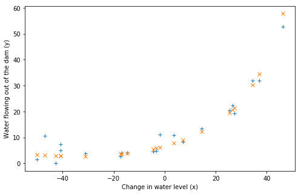

```python
plt.figure(figsize=(8,5))
plt.plot(Xval[0],yval,'+');
plt.plot(Xval[0],validation,'x')
plt.ylabel('Water flowing out of the dam (y)')
plt.xlabel('Change in water level (x)');
```

```python
#let's see the regularized regression coefficients:
print(regReg.coef_)
print(regReg.intercept_ )
```

```
[[2.67835450e-01 6.10254114e-03 7.74911263e-05 1.35308049e-06
  2.09694585e-08 3.16920841e-10 6.15718317e-12 6.55912613e-14]]
[6.67832161]
```

Notice that $\theta_0 =6.68$ and $\theta_1=0.27$ are comparable in magnitude to the same coefficients in the first regression we did, which didn't use regularization.